# Vignette Title

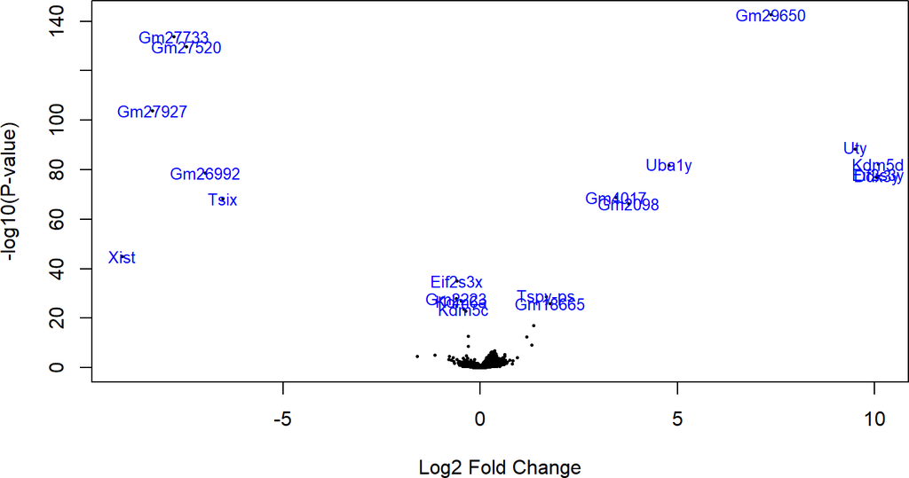

```r
miau <- volcanoplot(eb_results, coef = 2, highlight = 20, names = de_results$gene_name)
```

[age|Sex|genotype|tissue]

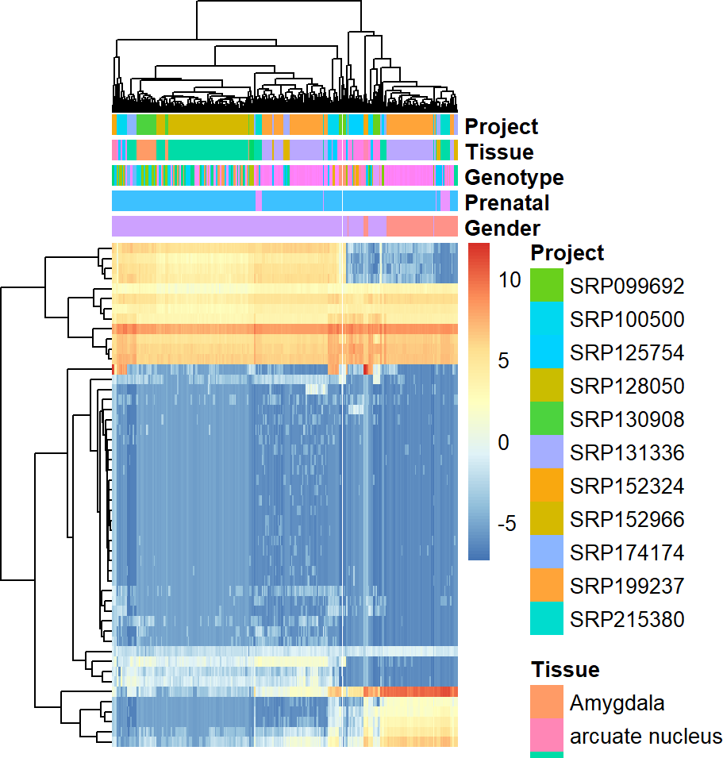

```r
## Extraer valores de los genes de interés
exprs_heatmap <- vGene$E[rank(de_results$adj.P.Val) <= 50, ]

## Creemos una tabla con información de las muestras
## y con nombres de columnas más amigables
df <- as.data.frame(colData(joined_data)[, c("sra_attribute.Sex", "prenatal","sra_attribute.genotype","sra_attribute.tissue","study")])
colnames(df) <- c("Gender", "Prenatal", "Genotype", "Tissue", "Project")



## Hagamos un heatmap
library("pheatmap")
pheatmap(
    exprs_heatmap,
    cluster_rows = TRUE,
    cluster_cols = TRUE,
    show_rownames = FALSE,
    show_colnames = FALSE,
    annotation_col = df
)
```

Cambiar brain a prenatal bran

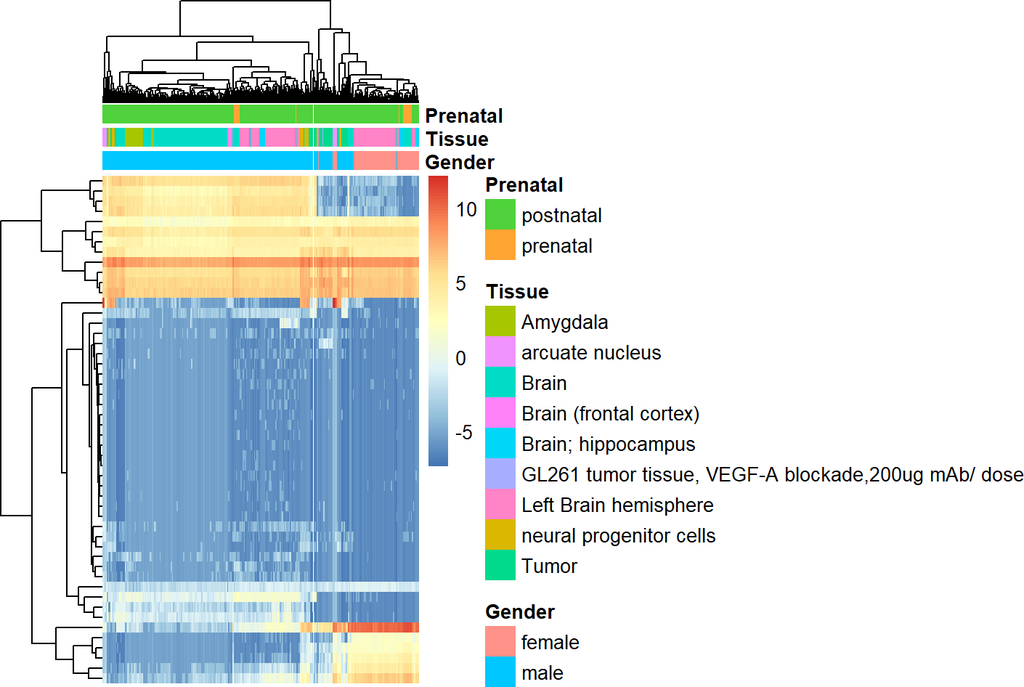

```r
## Extraer valores de los genes de interés
exprs_heatmap <- vGene$E[rank(de_results$adj.P.Val) <= 50, ]

## Creemos una tabla con información de las muestras
## y con nombres de columnas más amigables
df <- as.data.frame(colData(joined_data)[, c("sra_attribute.Sex","sra_attribute.tissue","prenatal")])
colnames(df) <- c("Gender", "Tissue",'Prenatal')

## Hagamos un heatmap
library("pheatmap")
pheatmap(
    exprs_heatmap,
    cluster_rows = TRUE,
    cluster_cols = TRUE,
    show_rownames = FALSE,
    show_colnames = FALSE,
    annotation_col = df
)
```

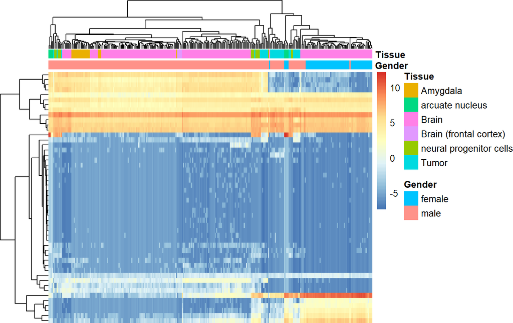

```r
## Extraer valores de los genes de interés
exprs_heatmap <- vGene$E[rank(de_results$adj.P.Val) <= 50, ]

## Creemos una tabla con información de las muestras
## y con nombres de columnas más amigables
df <- as.data.frame(colData(joined_data)[, c("sra_attribute.Sex","sra_attribute.tissue")])
colnames(df) <- c("Gender",'Tissue')

df$Tissue <-  gsub('Brain; hippocampus', 'Brain', df$Tissue )
df$Tissue <-  gsub(names(table(df$Tissue)[4]), 'Brain', df$Tissue )
df$Tissue <-  gsub('Left Brain hemisphere', 'Brain', df$Tissue )
df$Tissue <-  gsub('Left Brain hemisphere', 'Brain', df$Tissue )
df$Tissue <-  gsub('GL261 tumor tissue, VEGF-A blockade,200ug mAb/ dose', 'Tumor', df$Tissue )

## Hagamos un heatmap
library("pheatmap")
pheatmap(
    exprs_heatmap,
    cluster_rows = TRUE,
    cluster_cols = TRUE,
    show_rownames = FALSE,
    show_colnames = FALSE,
    annotation_col = df
)
```

# Figures

# 6 Equations

To number and reference equations, put them in equation environments and assign labels to them, see Equation (1).

$$\begin{equation}
f\left(k\right) = \binom{n}{k} p^k\left(1-p\right)^{n-k}
\tag{1}
\end{equation}$$

# 7 Tables

Like figures, tables with captions will also be numbered and can be referenced, see Table 1.

Table 1: A simple table With caption.

| Fruit | Price |
| --- | --- |
| bananas | 1.2 |
| apples | 1.0 |
| oranges | 2.5 |

# 8 Cross-references

# 9 Side notes

Footnotes are displayed as side notes on the right margin, which has the advantage that they appear close to the place where they are defined.